# Hwk 3: Some of My Bestfriends are Zombies

[figure not shown]

Aghhhhhh!

### Load the Following Packages

```r
library(curl)
library(dplyr)
library(sciplot)
library(manipulate)
library(ggplot2)
```

### Challenges

1. I had a very hard time coming up with and keeping track of the variables I was using. This homework had a lot of information, and it got overwhelming at times.
2. I also read that we could not find standard deviation for question 1 using the sd() function, so I did it manually at first - but it got me the same answer.
3. I had a hard time with my box plots on question 2, but after looking through the modules/googling my issue, I was able to figure it out.
4. For question 3, I originally thought I needed to put height/weight/age in one plot, so I was having a really hard time. I then realized we probably need one plot showing age vs. weight and one showing age vs. height and had to compare them.
5. Lastly, I had a hard time with the sample function. I found a function that worked: sample_n.

### Reflection

#### I did my peer commentary for Julianna Dick.

1. What you learned from their code that helped improve your own code: I like that she put the histograms and qq plots next to each other. It allowed for a better comparison of the two in a more organized way to determine whether it was a normal distribution or not.
2. What you did in your own code that might help theirs: I did the following for my boxplots, which may be a less complicated/compact code for each variable: boxplot(height ~ gender, d, col = “green”, main = “Height in Relation to Gender”, xlab = “Gender”, ylab = “Height”). I enjoy using “~” to make boxplots - it is easier overall. I also used a t.test to find the CIs, which I am not sure if that was okay to use or not, but it finds it very easily.
3. What challenges you both faced in your code, if any that could be helped my comparison: We both seemed to have issues with creating 99 more samples. I was unable to get the looping method to work, and used a replicate() function instead.
4. Whether the annotation/commenting is readable and interpretable to you, and if not how it can be improved: It is readable and interpretable to me! She did a great job. I like the subdivisions of the different questions that are in her knitted file.

### Load the Data Set

```r
f <- curl("https://raw.githubusercontent.com/fuzzyatelin/fuzzyatelin.github.io/master/AN588_Fall23/zombies.csv")
d <- read.csv(f, header = TRUE, sep = ",", stringsAsFactors = FALSE) #Assign D as the vector for the data set
head(d)
```

```
##   id first_name last_name gender   height   weight zombies_killed
## 1  1      Sarah    Little Female 62.88951 132.0872              2
## 2  2       Mark    Duncan   Male 67.80277 146.3753              5
## 3  3    Brandon     Perez   Male 72.12908 152.9370              1
## 4  4      Roger   Coleman   Male 66.78484 129.7418              5
## 5  5      Tammy    Powell Female 64.71832 132.4265              4
## 6  6    Anthony     Green   Male 71.24326 152.5246              1
##   years_of_education                           major      age
## 1                  1                medicine/nursing 17.64275
## 2                  3 criminal justice administration 22.58951
## 3                  1                       education 21.91276
## 4                  6                  energy studies 18.19058
## 5                  3                       logistics 21.10399
## 6                  4                  energy studies 21.48355
```

#### Assign Each Varible to a Vector (Excluding D because this is the Main Data Set)

```r
a <- d$height
b <- d$weight
c <- d$age
e <- d$zombies_killed
f <- d$years_of_education
```

## Question 1

### Find the Means for Each Variable

```r
mean(a, na.rm=TRUE)
```

```
## [1] 67.6301
```

```r
mean(b, na.rm=TRUE)
```

```
## [1] 143.9075
```

```r
mean(c, na.rm=TRUE)
```

```
## [1] 20.04696
```

```r
mean(e, na.rm=TRUE)
```

```
## [1] 2.992
```

```r
mean(f, na.rm=TRUE)
```

```
## [1] 2.996
```

### Find the Standard Deviation Step-By-Step

```r
sqrt(sum((a-mean(a))^2/(length(a)-1)))
```

```
## [1] 4.310126
```

```r
sqrt(sum((b-mean(b))^2/(length(b)-1)))
```

```
## [1] 18.40106
```

```r
sqrt(sum((c-mean(c))^2/(length(c)-1)))
```

```
## [1] 2.965066
```

```r
sqrt(sum((e-mean(e))^2/(length(e)-1)))
```

```
## [1] 1.748426
```

```r
sqrt(sum((f-mean(f))^2/(length(f)-1)))
```

```
## [1] 1.676543
```

### Find the Standard Deviation with sd() Function

```r
sd(d$height, na.rm=TRUE)
```

```
## [1] 4.310126
```

```r
sd(d$weight, na.rm=TRUE)
```

```
## [1] 18.40106
```

```r
sd(d$age, na.rm=TRUE)
```

```
## [1] 2.965066
```

```r
sd(d$zombies_killed, na.rm=TRUE)
```

```
## [1] 1.748426
```

```r
sd(d$years_of_education, na.rm=TRUE)
```

```
## [1] 1.676543
```

## Question 2

### Plot Each Variable in Relation to Gender

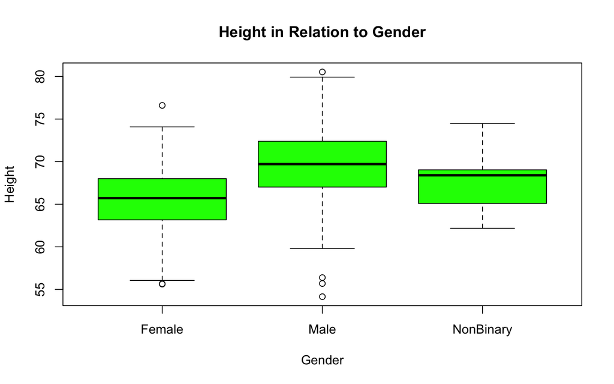

```r
boxplot(height ~ gender, d, col = "green", main = "Height in Relation to Gender", xlab = "Gender", ylab = "Height")
```

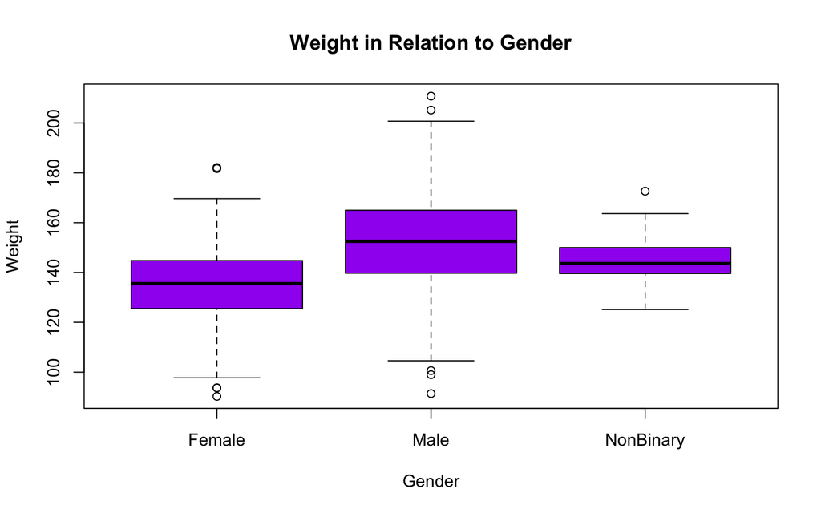

```r
boxplot(weight ~ gender, d, col = "purple", main = "Weight in Relation to Gender", xlab = "Gender", ylab = "Weight")
```

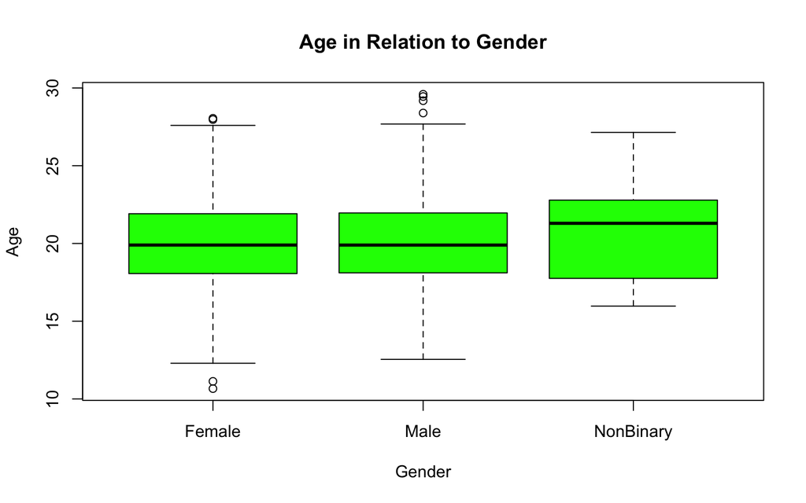

```r
boxplot(age ~ gender, d, col = "green", main = "Age in Relation to Gender", xlab = "Gender", ylab = "Age")
```

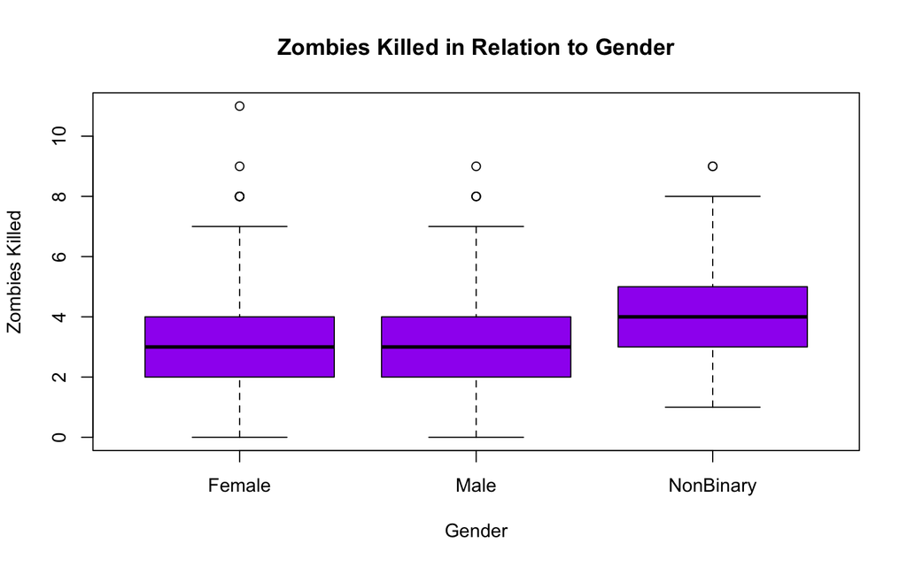

```r
boxplot(zombies_killed ~ gender, d, col = "purple", main = "Zombies Killed in Relation to Gender", xlab = "Gender", ylab = "Zombies Killed")
```

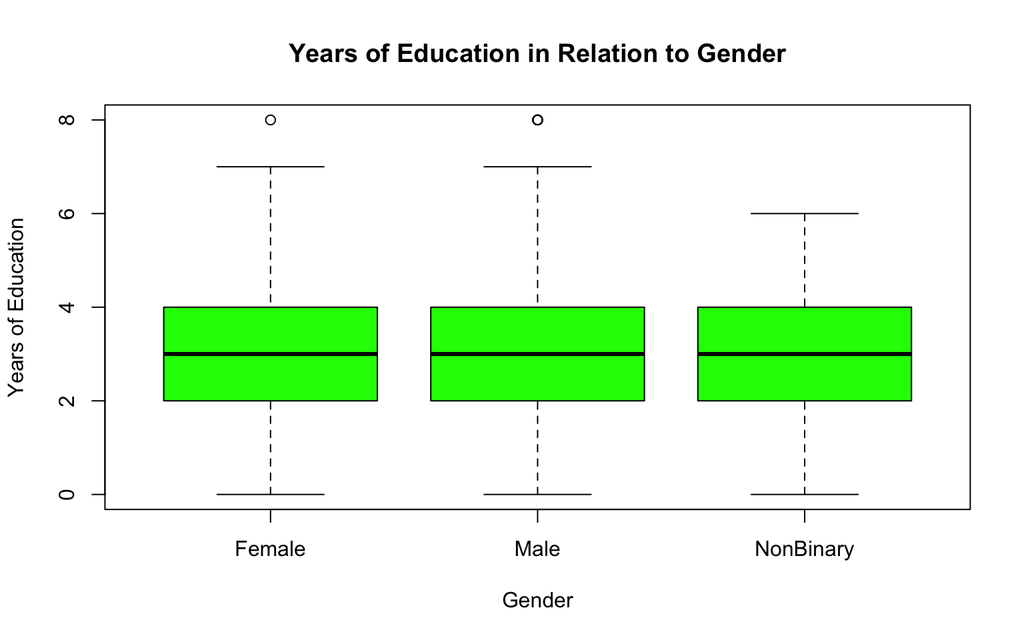

```r
boxplot(years_of_education ~ gender, d, col = "green", main = "Years of Education in Relation to Gender", xlab = "Gender", ylab = "Years of Education")
```

## Question 3

### Compare the Relationship between Height and Age vs Weight and Age

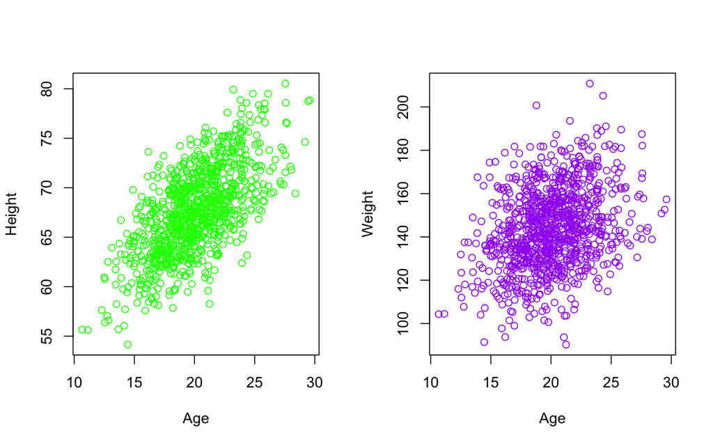

```r
par(mfrow = c(1, 2))
plot(x = d$age, y = d$height, col = "green", xlab="Age", ylab="Height")
plot(x = d$age, y = d$weight, col = "purple", xlab="Age", ylab="Weight")
```

## Question 4

### Graph Each Variable Using Histograms and Q-Q Plots

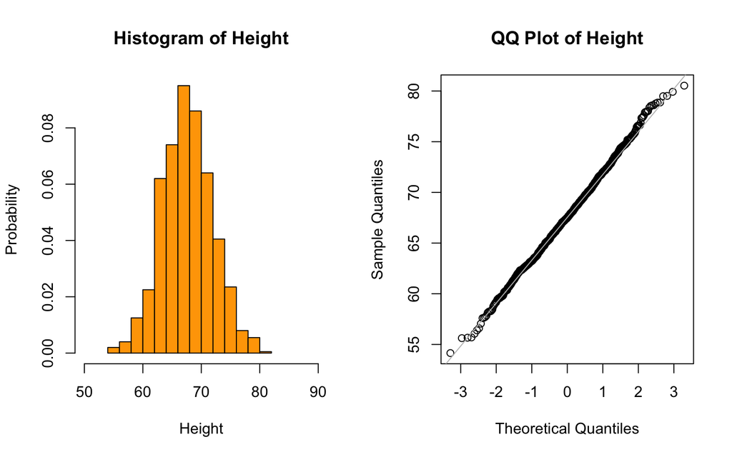

```r
par(mfrow=c(1,2))
hist(a, col = "orange", main = "Histogram of Height", xlim = c(50,90), xlab = "Height", ylab = "Probability", probability = TRUE)
qqnorm(a, main = "QQ Plot of Height" )
qqline(a,col="gray")
```

#### Based on the two graphs above, it can be concluded that height originates from a normal distribution.

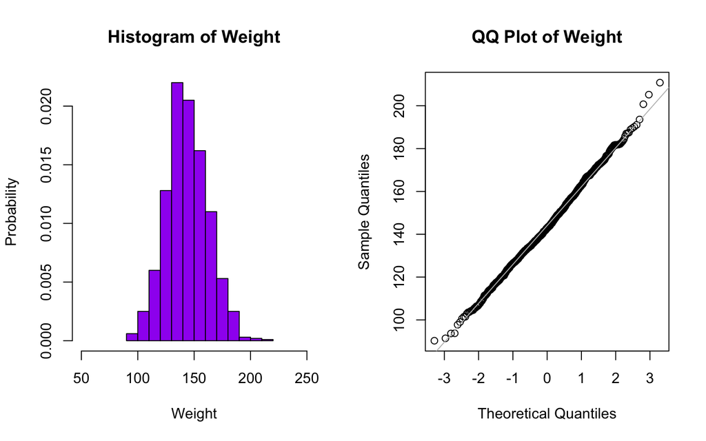

```r
par(mfrow=c(1,2))
hist(b, col = "purple", main = "Histogram of Weight", xlim = c(50,250), xlab = "Weight", ylab = "Probability", probability = TRUE)
qqnorm(b, main = "QQ Plot of Weight")
qqline(b,col="gray")
```

#### Based on the two graphs above, it can be concluded that weight originates from a normal distribution.

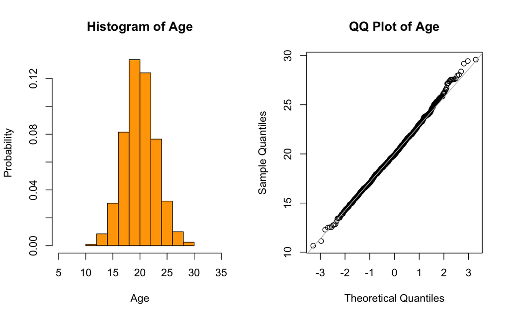

```r
par(mfrow=c(1,2))
hist(c, col = "orange", main = "Histogram of Age", xlim = c(5,35), xlab = "Age", ylab = "Probability", probability = TRUE)
qqnorm(c, main = "QQ Plot of Age" )
qqline(c,col="gray")
```

#### Based on the two graphs above, it can be concluded age originates from a normal distribution.

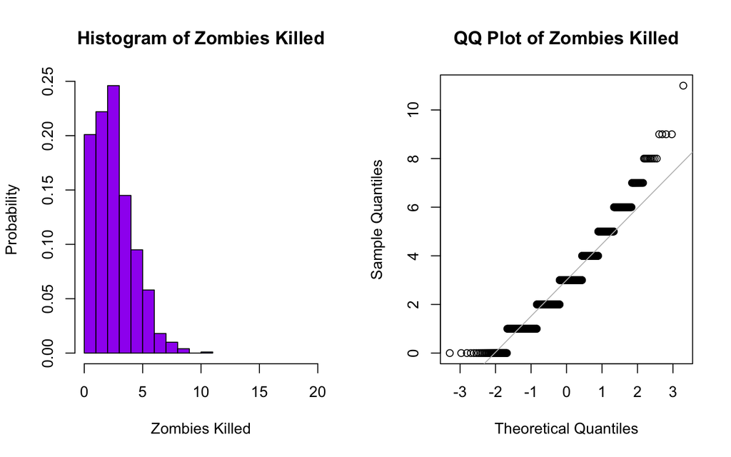

```r
par(mfrow=c(1,2))
hist(e, col = "purple", main = "Histogram of Zombies Killed", xlim = c(0,20), xlab = "Zombies Killed", ylab = "Probability", probability = TRUE)
qqnorm(e, main = "QQ Plot of Zombies Killed" )
qqline(e,col="gray")
```

#### Based on the two graphs above, it can be concluded that zombies killed does not originate from a normal distribution. It originates from a Poisson distribution.

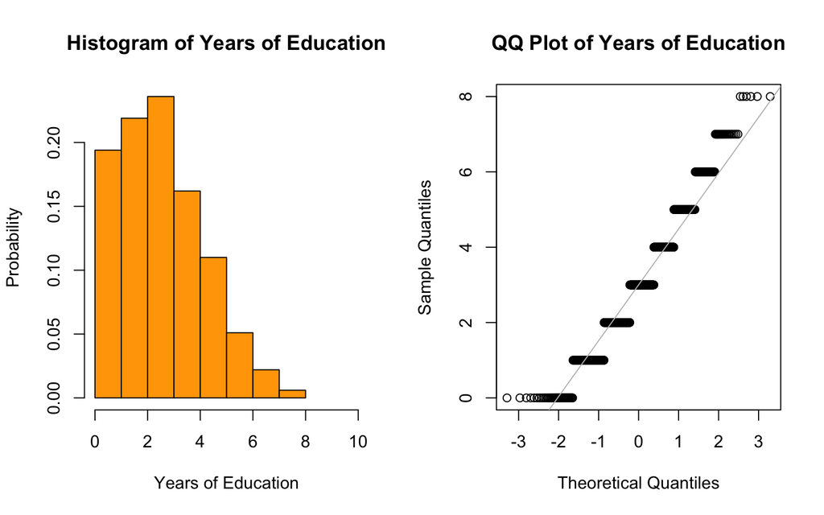

```r
par(mfrow=c(1,2))
hist(f, col = "orange", main = "Histogram of Years of Education", xlim = c(0,10), xlab = "Years of Education", ylab = "Probability", probability = TRUE)
qqnorm(f, main = "QQ Plot of Years of Education" )
qqline(f,col="gray")
```

#### Based on the two graphs above, it can be concluded that years of education does not originate from a normal distribution. It originates from a Poisson distribution.

## Question 5

### One Subset of 30 Zombies

```r
set.seed(1)
zombiesample <- sample_n(d, size = 30, replace = FALSE)
zombiesample
```

```
##     id  first_name last_name gender   height   weight zombies_killed
## 1  836       Susan   Hawkins Female 69.35963 133.1018              3
## 2  679    Benjamin      Ward   Male 61.95252 139.9611              2
## 3  129      Martin    Wagner   Male 70.26668 154.6746              2
## 4  930       Keith    Wagner   Male 63.24096 132.8480              3
## 5  509       Doris      Lane Female 62.33275 134.0491              3
## 6  471    Jennifer  Williams Female 62.29205 144.9394              2
## 7  299       Kelly     Burke Female 69.91124 145.7389              5
## 8  270 Christopher       Lee   Male 67.64806 130.5163              2
## 9  978      Willie  Richards   Male 64.73728 133.3641              5
## 10 187         Ann      Reid Female 71.02192 141.7984              2
## 11 307        Judy    Peters Female 63.76315 127.8650              4
## 12 597       Linda Patterson Female 63.14829 106.4643              2
## 13 277      Carlos Alexander   Male 75.21887 176.9457              3
## 14 874        Sean    Brooks   Male 68.52690 126.8207              1
```

[output cut: 47 more lines]

### Means of the One Subset of 30 Zombies for Each Variable

```r
mh <- mean(zombiesample$height)
mh
```

```
## [1] 66.88522
```

```r
mw <- mean(zombiesample$weight)
mw
```

```
## [1] 142.2536
```

```r
ma <- mean(zombiesample$age)
ma
```

```
## [1] 19.68657
```

```r
mk <- mean(zombiesample$zombies_killed)
mk
```

```
## [1] 3.066667
```

```r
me <- mean(zombiesample$years_of_education)
me
```

```
## [1] 2.966667
```

### Standard Deviations of the One Subset of 30 Zombies for Each Variable

```r
sd(zombiesample$height)
```

```
## [1] 3.735037
```

```r
sd(zombiesample$weight)
```

```
## [1] 16.22658
```

```r
sd(zombiesample$age)
```

```
## [1] 2.960476
```

```r
sd(zombiesample$zombies_killed)
```

```
## [1] 1.680175
```

```r
sd(zombiesample$years_of_education)
```

```
## [1] 1.691425
```

### Standard Errors of the One Subset of 30 Zombies for Each Variable

```r
se(zombiesample$height)
```

```
## [1] 0.6819214
```

```r
se(zombiesample$weight)
```

```
## [1] 2.962555
```

```r
se(zombiesample$age)
```

```
## [1] 0.5405065
```

```r
se(zombiesample$zombies_killed)
```

```
## [1] 0.3067566
```

```r
se(zombiesample$years_of_education)
```

```
## [1] 0.3088106
```

### 95% Confidence Intervals of 1 Subset of 30 Zombies Using a T-Test

```r
t.test(zombiesample$height)
```

```
##
##  One Sample t-test
##
## data:  zombiesample$height
## t = 98.083, df = 29, p-value < 2.2e-16
## alternative hypothesis: true mean is not equal to 0
## 95 percent confidence interval:
##  65.49053 68.27990
## sample estimates:
## mean of x
##  66.88522
```

```r
t.test(zombiesample$weight)
```

```
##
##  One Sample t-test
##
## data:  zombiesample$weight
## t = 48.017, df = 29, p-value < 2.2e-16
## alternative hypothesis: true mean is not equal to 0
## 95 percent confidence interval:
##  136.1945 148.3127
## sample estimates:
## mean of x
##  142.2536
```

```r
t.test(zombiesample$age)
```

```
##
##  One Sample t-test
##
## data:  zombiesample$age
## t = 36.422, df = 29, p-value < 2.2e-16
## alternative hypothesis: true mean is not equal to 0
## 95 percent confidence interval:
##  18.58111 20.79203
## sample estimates:
## mean of x
##  19.68657
```

```r
t.test(zombiesample$zombies_killed)
```

```
##
##  One Sample t-test
##
## data:  zombiesample$zombies_killed
## t = 9.9971, df = 29, p-value = 6.644e-11
## alternative hypothesis: true mean is not equal to 0
## 95 percent confidence interval:
##  2.439279 3.694054
## sample estimates:
## mean of x
##  3.066667
```

```r
t.test(zombiesample$years_of_education)
```

```
##
##  One Sample t-test
##
## data:  zombiesample$years_of_education
## t = 9.6068, df = 29, p-value = 1.627e-10
## alternative hypothesis: true mean is not equal to 0
## 95 percent confidence interval:
##  2.335078 3.598255
## sample estimates:
## mean of x
##  2.966667
```

## Question 6

### 99 Samples of 30 Zombies

#### You can use the replicate function to sample 99 more means of each variable

```r
set.seed(1)
z <- replicate(99, mean(sample(d$height, 30, replace = FALSE)))
y <- replicate(99, mean(sample(d$weight, 30, replace = FALSE)))
x <- replicate(99, mean(sample(d$age, 30, replace = FALSE)))
w <- replicate(99, mean(sample(d$zombies_killed, 30, replace = FALSE)))
v <- replicate(99, mean(sample(d$years_of_education, 30, replace = FALSE)))
```

### Output the 99 means for each variable

```r
z
```

```
##  [1] 66.88522 68.87591 67.55642 67.82131 66.12282 67.75560 68.96298 68.72629
##  [9] 68.25662 67.34644 67.46850 68.48790 67.90815 66.46223 67.17929 67.41929
## [17] 66.77861 67.89433 67.59705 67.58312 67.04473 68.89480 66.92336 68.16357
## [25] 67.72504 67.55813 66.81456 68.50070 66.94469 67.29940 65.85217 68.23941
## [33] 68.12140 67.32140 67.65566 68.30752 66.72076 68.14459 67.42285 66.99642
## [41] 67.31347 67.52381 66.77268 68.81288 67.40709 68.49501 66.45562 68.36110
## [49] 69.58033 67.35813 67.53122 68.05417 67.73060 67.45653 68.26496 67.18840
## [57] 68.30841 68.15431 66.92694 66.99125 69.05291 67.27523 65.95765 67.50351
## [65] 67.87894 68.13365 67.70053 68.10645 66.98337 67.02734 65.67462 68.92601
## [73] 65.96257 68.36079 66.15464 68.00558 68.02888 68.26723 68.96295 68.04302
## [81] 67.49222 68.32738 68.43746 68.84892 68.28959 67.17357 67.27155 67.30406
## [89] 67.36160 68.40829 67.91663 68.40025 67.02514 67.00004 68.41396 67.83749
## [97] 68.64506 68.29957 66.77320
```

```r
y
```

```
##  [1] 148.6277 143.8609 139.3163 139.7634 139.0612 140.1606 138.2056 133.9069
##  [9] 144.4622 142.8154 138.3455 142.9959 141.2127 145.1605 144.7922 144.1744
## [17] 140.7788 144.4219 140.6071 147.4053 140.3582 146.7989 144.7004 151.3551
## [25] 147.1087 143.0346 140.5927 147.1599 142.5778 141.6903 141.6770 148.9801
## [33] 146.8042 140.7472 146.0570 148.4523 148.7231 146.7050 138.0776 138.7561
## [41] 147.6667 141.5813 140.8586 142.0463 145.9543 142.3763 146.4317 153.2176
## [49] 147.5318 141.9259 145.6922 143.9370 142.3245 141.8247 140.3350 144.3776
## [57] 142.2340 141.4456 140.6657 142.8757 142.9273 146.0033 142.3758 148.7086
## [65] 136.2329 140.3597 140.8564 142.7242 144.4728 144.5176 142.3289 140.8663
## [73] 143.2856 147.6993 143.5671 143.5473 149.0039 147.3044 144.9764 142.0804
## [81] 148.8936 143.0009 143.7007 145.6912 141.7334 143.3678 147.9796 150.1908
## [89] 136.3921 143.7627 150.4164 141.3841 141.8694 139.4497 146.9754 143.7664
## [97] 138.1500 142.2241 143.6315
```

```r
x
```

```
##  [1] 20.31689 20.72264 19.72427 20.95155 20.92744 20.59216 20.48675 20.12804
##  [9] 19.59541 19.99246 21.48612 19.79503 19.94630 19.65457 21.15442 20.23702
## [17] 21.06432 19.67656 20.90972 19.89270 20.48134 19.51286 20.20122 20.41653
## [25] 20.43920 19.21516 20.13755 18.97146 19.43079 20.07045 19.82381 19.82822
## [33] 19.85479 19.59854 19.95381 20.11503 20.19789 19.46425 19.55695 19.23287
## [41] 20.58753 19.71152 20.88724 19.33697 19.28669 20.38672 20.47949 19.41536
## [49] 20.80432 19.66429 19.81223 20.21912 20.22296 20.01453 19.69226 19.18687
## [57] 19.82185 19.50336 20.12799 20.60405 20.93051 20.05429 19.94030 19.91308
## [65] 20.06795 20.42793 20.78606 20.25794 21.13181 20.41379 19.56313 21.85277
## [73] 19.47467 20.03232 18.96323 19.71646 20.30327 19.87299 19.47302 20.13059
## [81] 19.96695 20.74347 20.77170 19.67907 20.50723 19.85775 19.66974 20.47107
## [89] 19.46361 19.96573 19.88372 20.15851 19.88434 19.69980 18.92317 20.05881
## [97] 20.34329 20.74821 19.01319
```

```r
w
```

```
##  [1] 2.866667 3.400000 2.966667 3.100000 3.166667 3.100000 2.833333 3.133333
##  [9] 2.566667 2.833333 3.333333 3.333333 2.500000 2.700000 2.866667 2.866667
## [17] 3.000000 3.433333 3.166667 2.533333 2.833333 2.866667 2.633333 3.400000
## [25] 3.333333 3.533333 2.800000 3.266667 2.966667 2.866667 3.100000 2.733333
## [33] 2.566667 2.700000 3.333333 2.600000 3.300000 3.000000 3.533333 3.233333
## [41] 2.533333 3.366667 3.100000 3.333333 2.633333 2.866667 3.000000 3.500000
## [49] 2.866667 2.900000 3.200000 3.266667 2.733333 2.733333 3.000000 3.166667
## [57] 3.066667 2.866667 3.200000 2.933333 3.000000 2.466667 3.233333 3.400000
## [65] 3.200000 2.866667 2.666667 2.800000 3.433333 2.833333 2.866667 3.066667
## [73] 3.000000 2.966667 3.066667 3.066667 3.533333 2.366667 2.766667 2.800000
## [81] 2.533333 3.100000 3.100000 3.166667 3.433333 2.466667 2.800000 3.033333
## [89] 2.733333 3.066667 3.066667 3.366667 2.500000 2.933333 3.000000 2.600000
## [97] 2.900000 2.433333 2.466667
```

```r
v
```

```
##  [1] 3.133333 2.700000 3.266667 2.666667 2.966667 2.900000 3.200000 3.066667
##  [9] 3.200000 3.133333 2.666667 3.100000 2.900000 2.833333 3.300000 3.333333
## [17] 2.900000 2.800000 2.833333 3.033333 2.666667 2.666667 3.133333 3.233333
## [25] 2.333333 2.933333 3.066667 3.066667 2.833333 3.066667 3.200000 3.500000
## [33] 2.633333 2.733333 3.166667 2.700000 3.166667 2.700000 3.200000 2.800000
## [41] 3.200000 2.833333 3.033333 3.133333 3.133333 3.000000 2.966667 3.366667
## [49] 2.833333 2.900000 2.933333 2.833333 2.633333 2.833333 3.133333 2.866667
## [57] 3.566667 2.733333 3.066667 3.466667 3.400000 2.866667 2.900000 3.000000
## [65] 3.200000 2.533333 3.000000 2.433333 2.933333 3.466667 2.866667 2.666667
## [73] 2.900000 3.000000 3.166667 3.100000 2.433333 2.700000 2.800000 3.266667
## [81] 2.866667 2.833333 3.900000 3.100000 2.366667 2.966667 2.966667 3.066667
## [89] 2.500000 3.266667 3.200000 3.000000 3.633333 3.033333 3.100000 3.100000
## [97] 2.766667 3.233333 2.933333
```

### Creating One Data Set of All 100 Means

```r
meanheights <- c(mh,z)
meanweights <- c(mw,y)
meanages <- c(ma,x)
meanzombiekills <- c(mk,w)
meanyearsedu <- c(me,v)
```

### Below are the 100 Means for Each Variable!

```r
meanheights
```

```
##   [1] 66.88522 66.88522 68.87591 67.55642 67.82131 66.12282 67.75560 68.96298
##   [9] 68.72629 68.25662 67.34644 67.46850 68.48790 67.90815 66.46223 67.17929
##  [17] 67.41929 66.77861 67.89433 67.59705 67.58312 67.04473 68.89480 66.92336
##  [25] 68.16357 67.72504 67.55813 66.81456 68.50070 66.94469 67.29940 65.85217
##  [33] 68.23941 68.12140 67.32140 67.65566 68.30752 66.72076 68.14459 67.42285
##  [41] 66.99642 67.31347 67.52381 66.77268 68.81288 67.40709 68.49501 66.45562
##  [49] 68.36110 69.58033 67.35813 67.53122 68.05417 67.73060 67.45653 68.26496
##  [57] 67.18840 68.30841 68.15431 66.92694 66.99125 69.05291 67.27523 65.95765
##  [65] 67.50351 67.87894 68.13365 67.70053 68.10645 66.98337 67.02734 65.67462
##  [73] 68.92601 65.96257 68.36079 66.15464 68.00558 68.02888 68.26723 68.96295
##  [81] 68.04302 67.49222 68.32738 68.43746 68.84892 68.28959 67.17357 67.27155
##  [89] 67.30406 67.36160 68.40829 67.91663 68.40025 67.02514 67.00004 68.41396
##  [97] 67.83749 68.64506 68.29957 66.77320
```

```r
meanweights
```

```
##   [1] 142.2536 148.6277 143.8609 139.3163 139.7634 139.0612 140.1606 138.2056
##   [9] 133.9069 144.4622 142.8154 138.3455 142.9959 141.2127 145.1605 144.7922
##  [17] 144.1744 140.7788 144.4219 140.6071 147.4053 140.3582 146.7989 144.7004
##  [25] 151.3551 147.1087 143.0346 140.5927 147.1599 142.5778 141.6903 141.6770
##  [33] 148.9801 146.8042 140.7472 146.0570 148.4523 148.7231 146.7050 138.0776
##  [41] 138.7561 147.6667 141.5813 140.8586 142.0463 145.9543 142.3763 146.4317
##  [49] 153.2176 147.5318 141.9259 145.6922 143.9370 142.3245 141.8247 140.3350
##  [57] 144.3776 142.2340 141.4456 140.6657 142.8757 142.9273 146.0033 142.3758
##  [65] 148.7086 136.2329 140.3597 140.8564 142.7242 144.4728 144.5176 142.3289
##  [73] 140.8663 143.2856 147.6993 143.5671 143.5473 149.0039 147.3044 144.9764
##  [81] 142.0804 148.8936 143.0009 143.7007 145.6912 141.7334 143.3678 147.9796
##  [89] 150.1908 136.3921 143.7627 150.4164 141.3841 141.8694 139.4497 146.9754
##  [97] 143.7664 138.1500 142.2241 143.6315
```

```r
meanages
```

```
##   [1] 19.68657 20.31689 20.72264 19.72427 20.95155 20.92744 20.59216 20.48675
##   [9] 20.12804 19.59541 19.99246 21.48612 19.79503 19.94630 19.65457 21.15442
##  [17] 20.23702 21.06432 19.67656 20.90972 19.89270 20.48134 19.51286 20.20122
##  [25] 20.41653 20.43920 19.21516 20.13755 18.97146 19.43079 20.07045 19.82381
##  [33] 19.82822 19.85479 19.59854 19.95381 20.11503 20.19789 19.46425 19.55695
##  [41] 19.23287 20.58753 19.71152 20.88724 19.33697 19.28669 20.38672 20.47949
##  [49] 19.41536 20.80432 19.66429 19.81223 20.21912 20.22296 20.01453 19.69226
##  [57] 19.18687 19.82185 19.50336 20.12799 20.60405 20.93051 20.05429 19.94030
##  [65] 19.91308 20.06795 20.42793 20.78606 20.25794 21.13181 20.41379 19.56313
##  [73] 21.85277 19.47467 20.03232 18.96323 19.71646 20.30327 19.87299 19.47302
##  [81] 20.13059 19.96695 20.74347 20.77170 19.67907 20.50723 19.85775 19.66974
##  [89] 20.47107 19.46361 19.96573 19.88372 20.15851 19.88434 19.69980 18.92317
##  [97] 20.05881 20.34329 20.74821 19.01319
```

```r
meanzombiekills
```

```
##   [1] 3.066667 2.866667 3.400000 2.966667 3.100000 3.166667 3.100000 2.833333
##   [9] 3.133333 2.566667 2.833333 3.333333 3.333333 2.500000 2.700000 2.866667
##  [17] 2.866667 3.000000 3.433333 3.166667 2.533333 2.833333 2.866667 2.633333
##  [25] 3.400000 3.333333 3.533333 2.800000 3.266667 2.966667 2.866667 3.100000
##  [33] 2.733333 2.566667 2.700000 3.333333 2.600000 3.300000 3.000000 3.533333
##  [41] 3.233333 2.533333 3.366667 3.100000 3.333333 2.633333 2.866667 3.000000
##  [49] 3.500000 2.866667 2.900000 3.200000 3.266667 2.733333 2.733333 3.000000
##  [57] 3.166667 3.066667 2.866667 3.200000 2.933333 3.000000 2.466667 3.233333
##  [65] 3.400000 3.200000 2.866667 2.666667 2.800000 3.433333 2.833333 2.866667
##  [73] 3.066667 3.000000 2.966667 3.066667 3.066667 3.533333 2.366667 2.766667
##  [81] 2.800000 2.533333 3.100000 3.100000 3.166667 3.433333 2.466667 2.800000
##  [89] 3.033333 2.733333 3.066667 3.066667 3.366667 2.500000 2.933333 3.000000
##  [97] 2.600000 2.900000 2.433333 2.466667
```

```r
meanyearsedu
```

```
##   [1] 2.966667 3.133333 2.700000 3.266667 2.666667 2.966667 2.900000 3.200000
##   [9] 3.066667 3.200000 3.133333 2.666667 3.100000 2.900000 2.833333 3.300000
##  [17] 3.333333 2.900000 2.800000 2.833333 3.033333 2.666667 2.666667 3.133333
##  [25] 3.233333 2.333333 2.933333 3.066667 3.066667 2.833333 3.066667 3.200000
##  [33] 3.500000 2.633333 2.733333 3.166667 2.700000 3.166667 2.700000 3.200000
##  [41] 2.800000 3.200000 2.833333 3.033333 3.133333 3.133333 3.000000 2.966667
##  [49] 3.366667 2.833333 2.900000 2.933333 2.833333 2.633333 2.833333 3.133333
##  [57] 2.866667 3.566667 2.733333 3.066667 3.466667 3.400000 2.866667 2.900000
##  [65] 3.000000 3.200000 2.533333 3.000000 2.433333 2.933333 3.466667 2.866667
##  [73] 2.666667 2.900000 3.000000 3.166667 3.100000 2.433333 2.700000 2.800000
##  [81] 3.266667 2.866667 2.833333 3.900000 3.100000 2.366667 2.966667 2.966667
##  [89] 3.066667 2.500000 3.266667 3.200000 3.000000 3.633333 3.033333 3.100000
##  [97] 3.100000 2.766667 3.233333 2.933333
```

### Calculating the Final Mean and Standard Deviation for Each Variable

```r
mean(meanheights)
```

```
## [1] 67.66543
```

```r
mean(meanweights)
```

```
## [1] 143.544
```

```r
mean(meanages)
```

```
## [1] 20.06324
```

```r
mean(meanzombiekills)
```

```
## [1] 2.977333
```

```r
mean(meanyearsedu)
```

```
## [1] 2.986333
```

```r
sd(meanheights)
```

```
## [1] 0.7908622
```

```r
sd(meanweights)
```

```
## [1] 3.507536
```

```r
sd(meanages)
```

```
## [1] 0.5685191
```

```r
sd(meanzombiekills)
```

```
## [1] 0.2913986
```

```r
sd(meanyearsedu)
```

```
## [1] 0.2734037
```

### Differences Between Standard Deviations (Question 6) and Standard Errors (Question 5)

```r
sd(meanheights)-se(zombiesample$height)
```

```
## [1] 0.1089408
```

```r
sd(meanweights)-se(zombiesample$weight)
```

```
## [1] 0.5449814
```

```r
sd(meanages)-se(zombiesample$age)
```

```
## [1] 0.0280126
```

```r
sd(meanzombiekills)-se(zombiesample$zombies_killed)
```

```
## [1] -0.01535803
```

```r
sd(meanyearsedu)-se(zombiesample$years_of_education)
```

```
## [1] -0.03540685
```

#### The standard deviations in question 6 are similar to the standard errors from question 5. The weight standard deviation and error seem to be the most different, while the zombies killed appears to be the most similar.

### Determining Normal Distribution

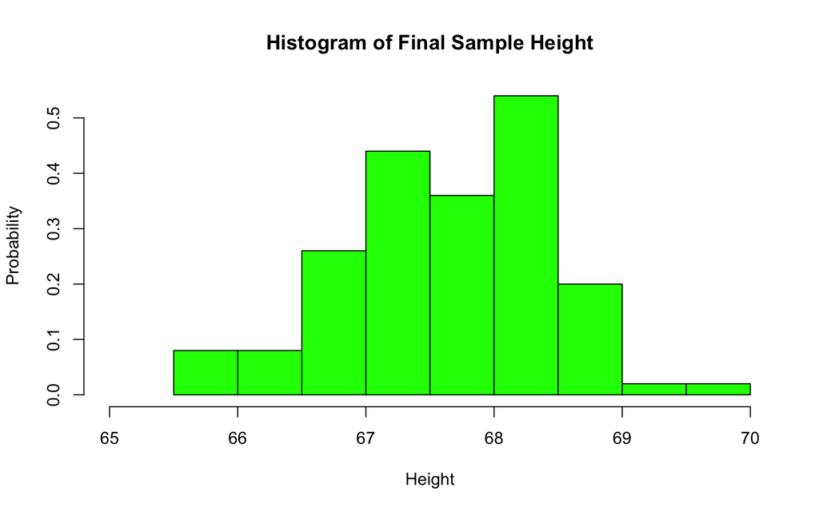

```r
hist(meanheights, col = "green", main = "Histogram of Final Sample Height", xlim = c(65,70), xlab = "Height", ylab = "Probability", probability = TRUE)
```

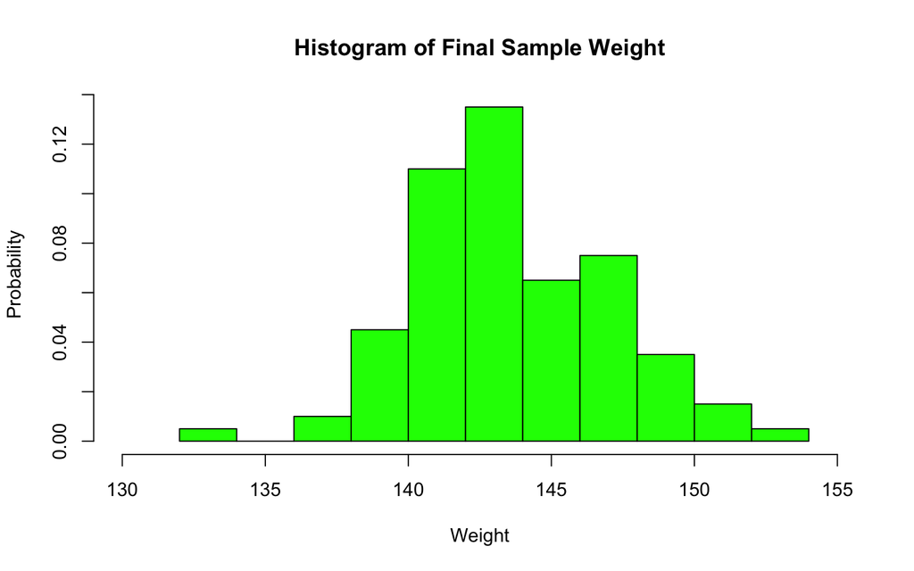

```r
hist(meanweights, col = "green", main = "Histogram of Final Sample Weight", xlim = c(130,155), xlab = "Weight", ylab = "Probability", probability = TRUE)
```

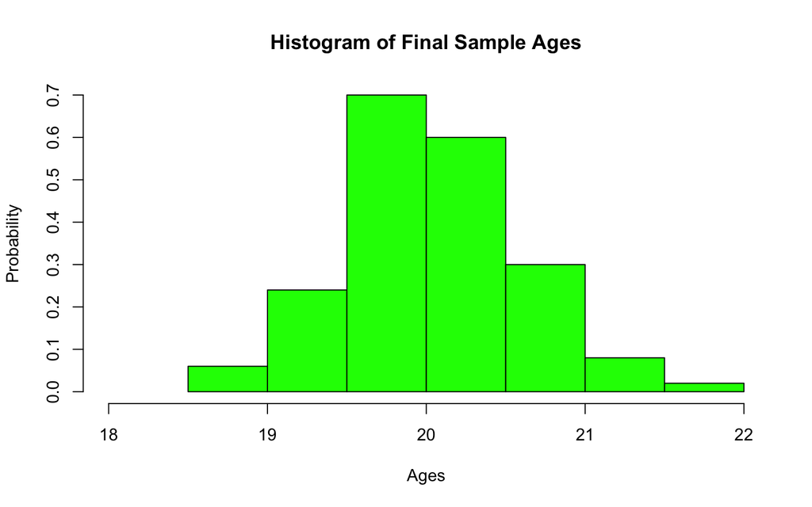

```r
hist(meanages, col = "green", main = "Histogram of Final Sample Ages", xlim = c(18,22), xlab = "Ages", ylab = "Probability", probability = TRUE)
```

#### Based on the graph above, it can be concluded age originates from a normal distribution.

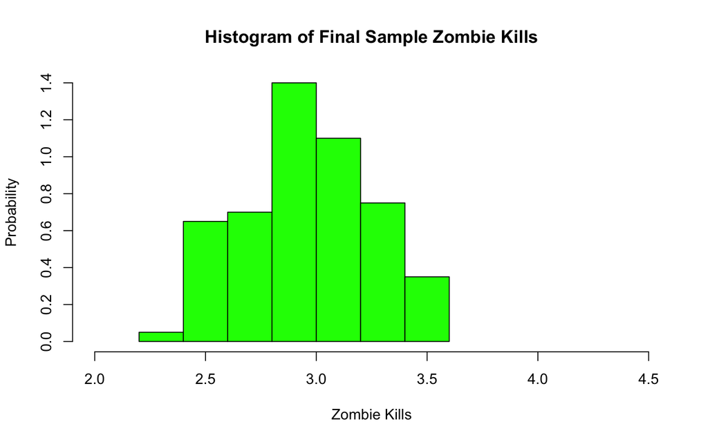

```r
hist(meanzombiekills, col = "green", main = "Histogram of Final Sample Zombie Kills", xlim = c(2,4.5), xlab = "Zombie Kills", ylab = "Probability", probability = TRUE)
```

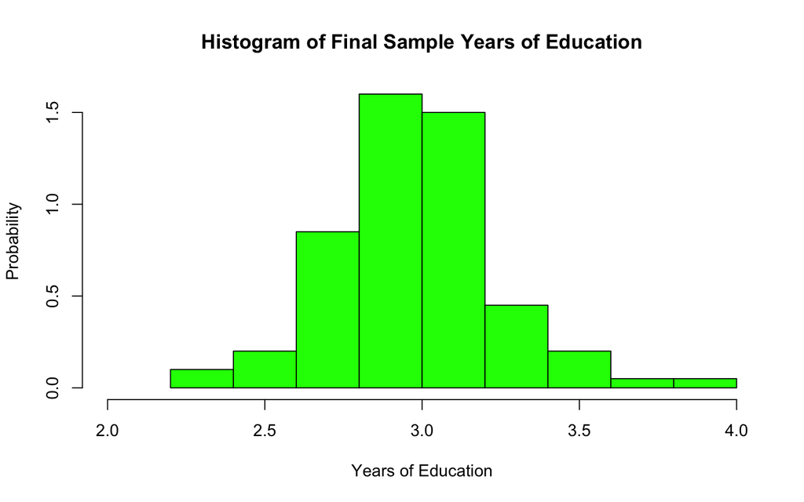

```r
hist(meanyearsedu, col = "green", main = "Histogram of Final Sample Years of Education", xlim = c(2,4), xlab = "Years of Education", ylab = "Probability", probability = TRUE)
```

Happy Spooky Season!